# **Introduction to producing allometric equations from linear models**

Featuring light data wrangling, log-transformations, and error quantifications

Luisa-Marie Dickenmann

November 2022

# Tutorial aims

- Apply and expand on the Coding Club tutorial “Transforming and Scaling Data”
- Use model outputs to produce allometric equations on preferred variables

# Steps

1. Subset preferred variables with `tidyr`
2. Modify the data to prepare it for the model
3. Apply an appropriate model
4. Extract relevant coefficients from the model to produce allometric equations
5. Quantify errors associated with the allometric equation

If you have ever created a model before, you remember the wealth of coefficients and significance values that it produces. Say your model is on two variables, but one of them was really difficult to measure and you only collected data from a few points of a possible range of values. Some of the coefficients from the model can be used to create create an allometric equation, which takes a variable that are easy to measure as an input to predict the variable that is difficult to measure.

However, similar to having a mean of a distribution that needs a standard deviation to be informative, the result from an allometric equation requires a measure of variation. How accurate is the value that it produces? To achieve that, we will compare our observed data with what the allometric equation would produce and produce a ‘root mean square error’.

This tutorial works with a large data set on destructively sampled biomass structure of trees in Eurasia, which can be found here: https://www.nature.com/articles/sdata201770#Sec3, and is a continuation of the [Transforming and Scaling Data](https://ourcodingclub.github.io/tutorials/data-scaling/) tutorial.

If you’d like to familiarise yourself with R Studio or linear models first, I highly recommend the Coding Club’s tutorials: [Getting Started with R and RStudio](https://ourcodingclub.github.io/tutorials/intro-to-r/) and [Intro to Model Design](https://ourcodingclub.github.io/tutorials/model-design/)

All the materials you need, including the data set, a full example script and the figures we will produce can be found in [this repository](https://github.com/luisasenecio/Allometric-equations-from-linear-models.git). Simply click on the green <> Code button

**Let’s get started then!**

## 1. Subset preferred variables with `tidyr`

First, we need to include a couple of libraries that will help us load and manipulate the data.

If you have created a new R Project for this tutorial and your data sets are in the same folder then you don’t need to set your working directory as R already knows where to look for it.

If you simply made a new R Script file, then please set your working directory to where your files are stored with `setwd("file_path")``.

# 2. Investigate the distribution of the variables

Every model has its own requirements about the data. A general linear model for example would like the data to be normally distributed, meaning a bell-shaped distribution where intermediate values are most frequent, and observations trail off towards the extremes of the range. The model also assumes that the relationship between the variables is actually linear. If we think about our variables logically, trees with larger diameters should also have a greater total biomass, so it’s not unrealistic to assume a linear relationship between DBH and total biomass.

However, as for the normal distribution we might run into a few problems. There are many small trees around, but not an equal number of medium or very large trees because not every sapling survives to become mature.

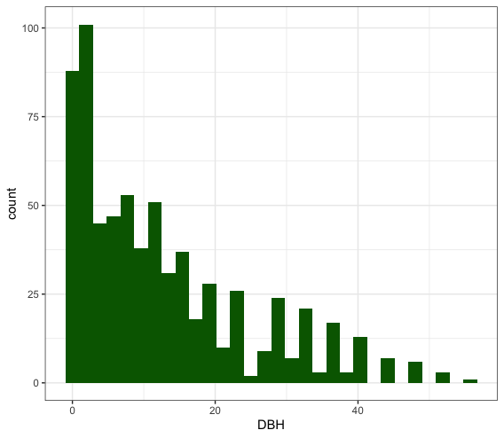

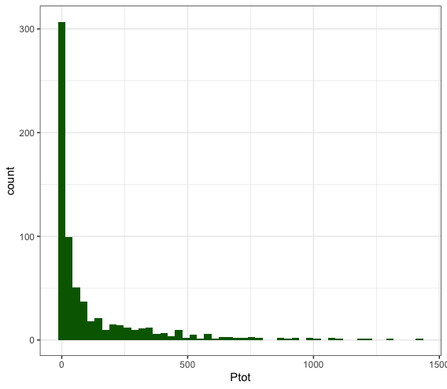

The distribution of the response variable (total live biomass) is even more right-skewed.

**But be careful here since log10 transformations only work with positive data!** Neither DBH or total live biomass can be below 0, so this is no problem for us here.

If you find when you’re plotting your distributions that the data is not that extremely right-skewed, you can try applying a weaker square root transformation.

We can now have a look if our transformations have worked by plotting another set of histograms but this time with the transformed data.

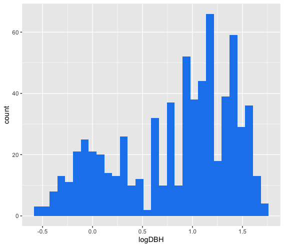

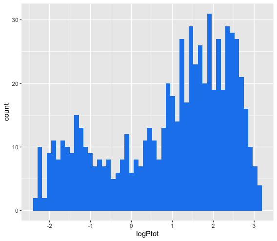

This looks much better than before and we can see how the assumptions for a linear model are now met by visualising the relationship between the log-transformed variables.

Which produces this:

[figure not shown]

We can now build a linear model!

# 3. Building the model

The coefficients that we need are in the red box in the summary output below.

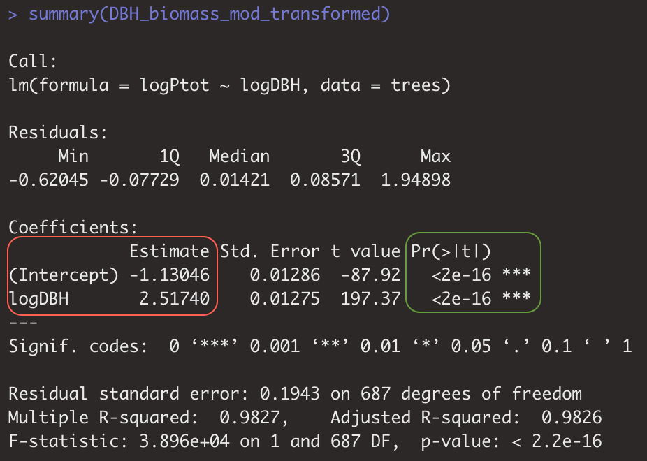

The green box shows the p value and it seems like the relationship between explanatory (DBH) and response (total biomass) variables are highly significant with a p value of less than 0.05 and a small standard error!

Before we proceed, we should make sure that our model actually fulfills the assumptions of normality.

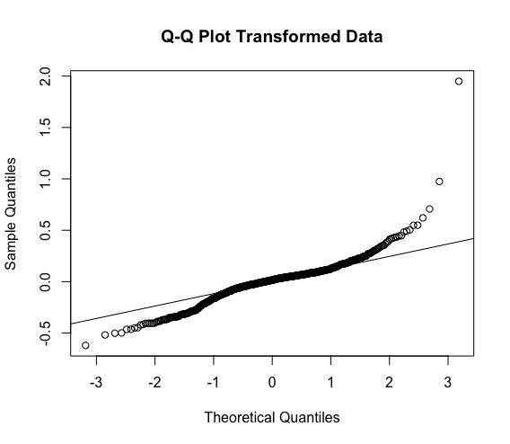

However, our model outputs are in units of log10 transformed data. To actually be able to predict anything with our model, we need to back-transform our data.

If you compare the original data with the back-transformed data, they should match relatively closely.

# 4. Extracting the coefficients for an allometric model

As mentioned above, we need the coefficients from the red box. The estimate for `intercept`` is indeed the intercept, which is technically the value for total live biomass when DBH = 0. However, because we have log10 transformed the data, the intercept is now negative and carries little applicable meaning. It is however very useful to build the equation of a straight line.

The second coefficient we need is the estimate for `logDBH``.

If we combine them together into an equation for a straight line, we get:

Which is the allometric equation to calculate total live biomass from DBH measurements.

# 5. Error quantification

The equation on its own is a good start, but we need to be able to give an indication of the accuracy of the resulting total biomass.

To do this, we calculate the root means square error (RMSE) by comparing the actual measured data with what our model would predict the response variable to be.

The difference is calculated by subtracting the predicted biomass from the observed, but log10 transformed biomass. This produces a measure of error for each tree, which can be summed together to produce an RMSE for the entire allometric equation.

**Careful!** This equation and its associated RMSE is only accurate for the range of observed values it was created from. But because our DBH measurements ranged from 0.3 to 56 cm and total live biomass ranged from 0.005 to 1’420.5 kg, a lot of different tree sizes are covered by it.